[GitHub Python Bar Review](https://github.com/ckorikov/python-bar-review)

# Итераторы, генераторы и функциональное программирование

## 1. Итераторы — потоки данных

**Итератор** — объект в Python, который является объектным представлением потока данных. Говорят, что объект реализует протокол итератора, если объект:

- имеет метод `__iter__()`, который возвращает объект с методом `__next__()`,
- `__next__()` вызывает исключение `StopIteration`, когда поток данных закончился.

О таком объекте говоря, что он итерируемый (`iterable`). Итерируемый объект возвращает через `__iter__()` итератор (`iterator`).

Например, список итерируемый. У него можно найти `__iter__()`.

```python
# Список итерируемый
import inspect
inspect.getmembers([1,2,3])
```

[output not shown]

Для работы с итераторами в Python есть две вспомогательные функции: `iter` и `next`. Первая возвращает итератор, вторая — следующее значение итератора.

```python
# Вспомогательные функции для работы с итераторами
lst = [1,2,3]
itr = iter(lst)
next(itr), next(itr), next(itr)
```

```
(1, 2, 3)
```

```python
# Если поток закончился, то next вызовет исключение (должн быть ошибка)
next(itr)
```

```
---------------------------------------------------------------------------
StopIteration                             Traceback (most recent call last)
<ipython-input-3-1fa880664e34> in <module>
      1 # Если поток закончился, то next вызовет исключение (должн быть ошибка)
----> 2 next(itr)

StopIteration:
```

### Пример своего итерируемого объекта

Опишем объект, который возвращает целые числа от `value` до «бесконечности» с шагом `step`. Здесь сам объект имеет метод `__next__()`, поэтому в `__iter__()` он возвращает сам себя. При этом объект и итерируемый и итератор одновременно.

```python
# Пример итерируемого объекта
class Counts:
    def __init__(self, start=0, step=1):
        self.value = start
        self.step = step
    def __iter__(self):
        return self
    def __next__(self):
        self.value += self.step
        return self.value

s = Counts(step=2)
next(s), next(s), next(s)
```

```
(2, 4, 6)
```

**NB!** Итератор `Counts` уже реализован в модуле itertools.

## 2. Генераторы — упрощенные итераторы

**Генератор** — «синтаксический сахар» для итератора. С точки зрения синтаксиса, генератор — функция с ключевым словом `yield` внутри.

Чтобы сгенерировать значение, надо в `next` передать генератор. Внутри происходит следующее:

1. функция-генератор выполняется до первой инструкции `yield val`,
2. вычисление функции ставится на паузу,
3. возвращается значение `val`.

Для примера перепишем итератор `Counts` как генератор.

```python
def counts(value=0, step=1):
    while 1:
        value += step
        yield value

g = counts(step=2)
type(g), next(g), next(g), next(g)
```

```
(generator, 2, 4, 6)
```

## 3. Включения в список и выражения-генераторы

- **Включения в список** (англ. list comprehensions) — «синтаксический сахар» для создания списков.
- **Выражения-генераторы** (англ. generator expressions) — «синтаксический сахар» для создания генераторов.

Синтаксически конструкции похожи.

```python
# Включение в список
lstcomp = [x*x for x in range(10)]
type(lstcomp), lstcomp
```

```
(list, [0, 1, 4, 9, 16, 25, 36, 49, 64, 81])
```

```python
# Выражение-генератор
genexpr = (x*x for x in range(10))
type(genexpr), next(genexpr), next(genexpr), next(genexpr)
```

```
(generator, 0, 1, 4)
```

Генератор — это процедура получения значений последовательности данных. Поэтому размер генератора меньше, чем непосредственно списка значений последовательности данных.

```python
# Размер списка vs размер генератора
from sys import getsizeof

data_a = [i for i in range(1000000)]
data_b = (i for i in range(1000000))

getsizeof(data_a), getsizeof(data_b)
```

```
(8697456, 112)
```

Генерация списка с помощью генераторов работает медленнее из-за затрат на вызов функции:

```python
%timeit [i for i in range(1000000)]
```

```
118 ms ± 28.1 ms per loop (mean ± std. dev. of 7 runs, 10 loops each)
```

```python
%timeit list(i for i in range(1000000))
```

```
170 ms ± 68.9 ms per loop (mean ± std. dev. of 7 runs, 1 loop each)
```

## 4. Функциональное программирование

Python — мультипарадигменный язык программирования. На нем можно писать в

- процедурном,
- объектно-ориентированном
- или функциональном стиле.

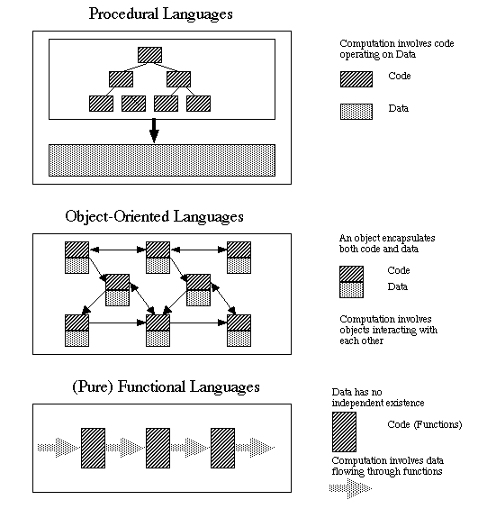

Программа в **функциональном стиле** выглядит как последовательное применение функций к входным данным. Результат каждой их этих функций зависит только от её аргументов. Такие функции называют **чистыми функциями**. У нечистых функции есть побочные эффекты).

Обычно, если язык программирования поддерживает функциональный стиль, то в нём реализованы:

- анонимные функции (лямбда-функции)
- функции высших порядков.

## 5. Лямбда-функция — функции одного выражения

Лямбда-функция определеяются с помощью ключевого слова `lambda`. Объявление лямбда-функции аналогично объявлению функции с помощью `def`, только

- в одну строчку,
- без имени,
- с неявным `return`.

```python
# Лябда-функция
type(lambda x: x*x)
```

```
function
```

```python
# Применение лябда-функции
(lambda x, y: x+y)(2,3)
```

```
5
```

```python
# Применение лябда-функции как обычной функции
f=lambda x, y: x+y
f(2,3)
```

```
5
```

#### Где применять лямбда-функции?

Например:

- для компактного описания замыканий,
- для конфигурирования функций высшего порядка (см. следующий раздел).

```python
# Лябда-функция в замыканиях
def gen_mul(a):
    return lambda b: a*b

double=gen_mul(2)
double(3)
```

```
6
```

**NB!** Если беглым взглядом непонятно что делает лямбда-функция, то лучше ее реализовтаь как обычную функцию.

## 6. Функции высшего порядка

### Map, Reduce и Filter

Функции `map` и `filter` встроены в язык, а `reduce` находится в модуле `functools`.

[figure not shown]

Функция `map` выполняет отображение одной последовательности в другую, применяя к каждом элементу одну и ту же фукнцию.

Условно `map` работает так:

```
[a,b,c] -> [f(a),f(b),f(c)]
```

```python
# Пример: взять для каждого элемента квадрат
map(lambda x: x*x, [1,2,3])
```

```
<map at 0x10ecbc730>
```

`map` возвращает итератор. Удобно преобразовать к списку:

```python
# Пример: взять для каждого элемента квадрат
list(map(lambda x: x*x, [1,2,3]))
```

```
[1, 4, 9]
```

Функция `filter` выполняет фильтрацию входной последовательности, оставляя только те элементы, которые удовлетворяют критерию.

Условно `filter` работает так:

```
[a,b,c] -> {x != b} -> [a,c]
```

```python
# Пример: оставить элементы только больше 2
list(filter(lambda x: x>2, [1,2,3]))
```

```
[3]
```

Функция `reduce` выполняет сворачивание входной последовательности к одному значению, применяя последовательно функцию.

Условно `reduce` работает так:

```
[a,b,c] -> f[f[a,b],c]
```

```python
# Пример 1: сумма элементов последовательности
from functools import reduce
reduce(lambda x,y: x+y, [1,2,3], 0)
```

```
6
```

```python
# Пример 2: скалярное произведение
from functools import reduce
a = [1,2,3]
b = [6,0,4]
reduce(lambda x,y: x+y[0]*y[1], zip(a,b), 0)
```

```
18
```

Здесь `zip` — вспомогательная функция высшего порядка, которая собирает из двух последовательностей одну по такому правилу:

```
zip([a1,a2,a3],[b1,b2,b3]) -> [(a1,b1), (a2,b2), (a3,b3)]
```

## Почитать

- [Functional Programming HOWTO](https://docs.python.org/3.7/howto/functional.html)

```python
%load_ext watermark
%watermark -d -u -v -iv
```

```
last updated: 2019-10-21

CPython 3.8.0
IPython 7.8.0
```